# Homework 2

Saif Farooq

2025-09-18

## Introduction

The given data set appears to be a comprehensive list of 200 of the world’s tallest buildings (≥290m) existing or being completed as of 2025 compiled by the **Council on Tall Buildings and Urban Habitat**. The data set contains relevant details about each edifice such as its location (city), height (m), construction status, material, etc.

> I will be investigating the height distribution of these buildings, the relationship between their completion year and height, as well as the relationship between the number of floors each building has/will have and whether it has been completed.

## Research Question 1

### How tall are the world’s tallest buildings?

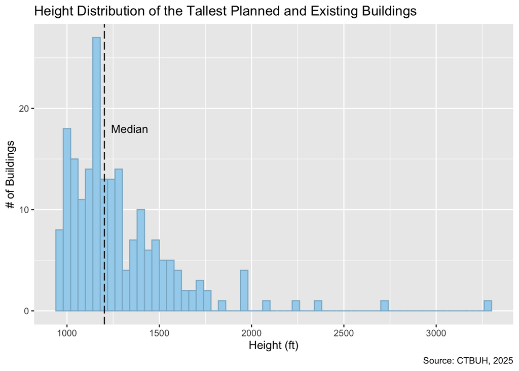

```r
TallBuildD$HeightF <- TallBuildD$Height * 3.28084
TBD_ggplot <-  ggplot(TallBuildD)
TBD_ggplot + geom_histogram(aes(x=HeightF), binwidth = 40, col = "lightskyblue3", fill = "lightskyblue2") +
  geom_vline(xintercept = median(TallBuildD$HeightF), col = "black", linetype = 5) +
  annotate("text", x = 1340, y = 18, label = "Median", col = "black") +
  labs(title="Height Distribution of the Tallest Planned and Existing Buildings", x = "Height (ft)", y = "# of Buildings", caption = "Source: CTBUH, 2025")
```

As depicted above, the graph is positively skewed toward the right. It has a median of **1202.428** and an interquartile range of **309.219**.

This illustrates that most of the buildings in this data set roughly have a height between **1000** and **1500** feet.

## Research Question 2

### For completed buildings, is there a relationship between the year it was completed and height?

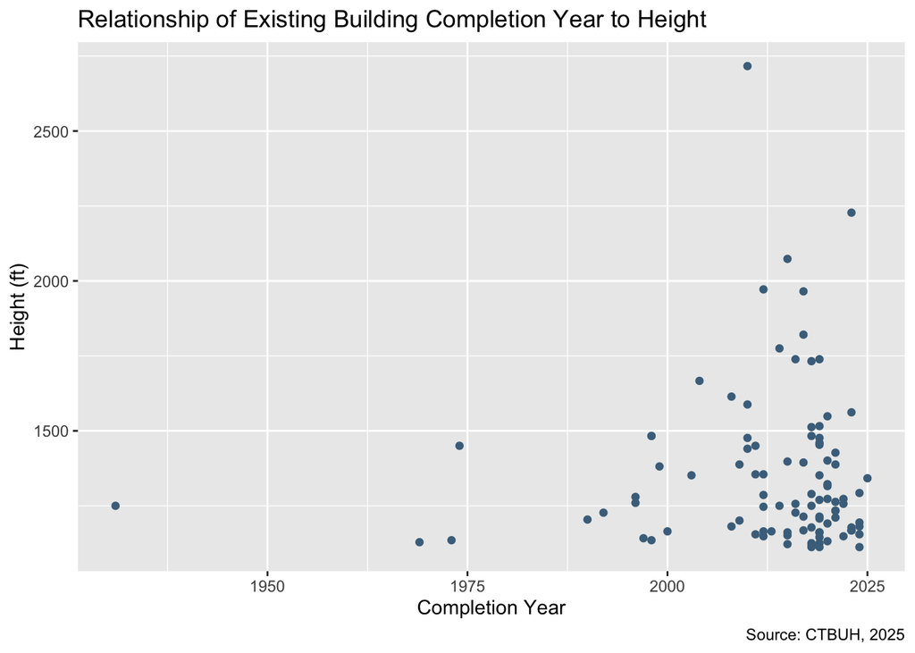

```r
CompBuildD <- TallBuildD[TallBuildD$Status == "Completed",]
CB_ggplot <- ggplot(CompBuildD)
CB_ggplot + geom_point(aes(x = CompletionYear, y = HeightF), col = "skyblue4") +
  labs(title="Relationship of Existing Building Completion Year to Height", x = "Completion Year", y = "Height (ft)", caption = "Source: CTBUH, 2025")
```

According to the data from the scatterplot above of the relationship between a constructed building’s completion year and its height, the pearson correlation between the two variables is **0.039**.

Although there is a slight tendency for taller buildings to be constructed in recent years as shown by the scatter plot, this indicates that there is a **weak relationship** between the completion year and height as evidenced by the low pearson correlation, and many buildings, at this time, are still being constructed with a final height **<1500 feet**.

## Research Question 3

### “How does the number of floors differ between completed buildings and buildings still under construction?”

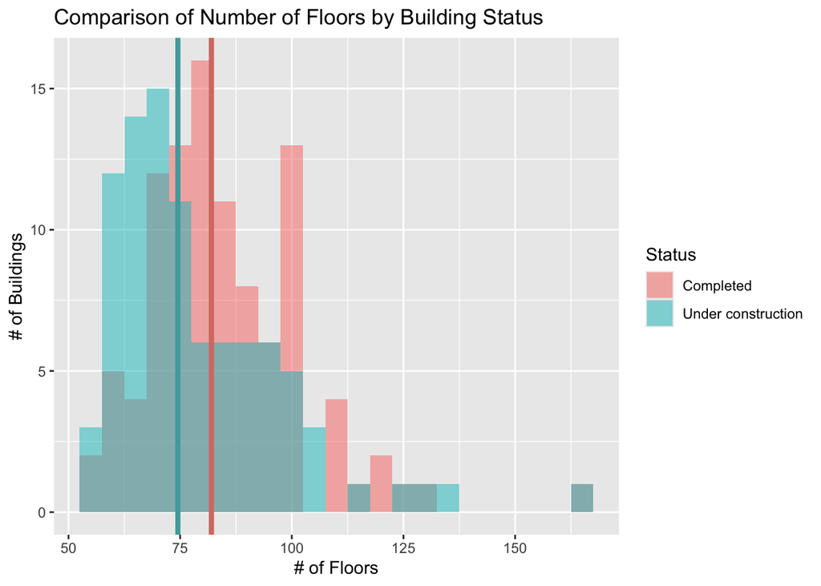

```r
UncompBuildD <- TallBuildD[TallBuildD$Status == "Under construction",]
TBD_ggplot + geom_histogram(aes(x=Floors,fill=Status), alpha=.5, binwidth=5, position='identity', na.rm=TRUE) +
  geom_vline(xintercept = median(CompBuildD$Floors, na.rm = TRUE),col = "#d87c74",linetype = 1,linewidth = 1.5) +
  geom_vline(xintercept = median(UncompBuildD$Floors, na.rm = TRUE),col = "#50a8ab",linetype = 1,linewidth = 1.5) +
  labs(title="Comparison of Number of Floors by Building Status", x = "# of Floors", y = "# of Buildings")
```

Both graphs of the completed and under construction buildings are skewed to the right with the completed buildings being slightly less skewed than the ones under construction. The former has a median of **82** and an interquartile range of **22**, while the latter has a median of **74.5** and an interquartile range of **24**. As evidenced by the median, it can be observed that the buildings under construction tend to have slightly less floors compared to that of existing buildings.

## Conclusion

The first analysis of the distribution of the collective building heights resulted in the finding that most of the buildings had a height between **1000** and **1500** feet. The second analysis of the relationship of a finished building’s completion year and its height resulted in a **very weak and slightly positive correlation**. Lastly, the graph comparing the number of floors between completed and uncompleted buildings resulted in the finding that uncompleted buildings had **slightly less** planned floors than completed ones.